# GGIS 224 - Lab 7

Jonathan Bernard Widjajakusuma, Environmental Data Science @UIUC

2/29/2024

## Overview

This lab is dedicated to raster analysis and raster-vector interactions.

In our previous lectures, We emphasized attribute operations, spatial operations, and geometric operations primarily using vector data. The same concepts and operations also apply to raster data. Given the expectation that you have mastered the materials for vector data, you should be able to self-study [Section 4.3. Spatial operations on raster data](https://r.geocompx.org/spatial-operations), [Section 5.3. Geometric operations on raster data](https://r.geocompx.org/geometry-operations), and [Chapter 6. Raster-vector interactions](https://r.geocompx.org/raster-vector) and learn how the concepts and operations can be applied to raster data and how both data types can be used interactively.

After you have gone through Section 4.3, Section 5.3, and Chapter 6, explore the following interesting questions.

Don’t forget to comment your code while answering the questions below.

Render your completed RmD document by clicking on the “Knit” option in RStudio. Upload the .html file to your lab submission. Your uploaded .html file should follow this naming convention: Lab7_FirstNameInitial_LastName.html (for example, Lab7_E_Hall.html).

## Environment Setup

Load up all libraries needed for this lab.

```r
library(sf)
library(terra)
library(dplyr)
library(spData)
```

Some of the following exercises use a vector (zion_points) and raster dataset (srtm) from the spDataLarge package. They also use a polygonal ‘convex hull’ derived from the vector dataset (ch) to represent the area of interest.

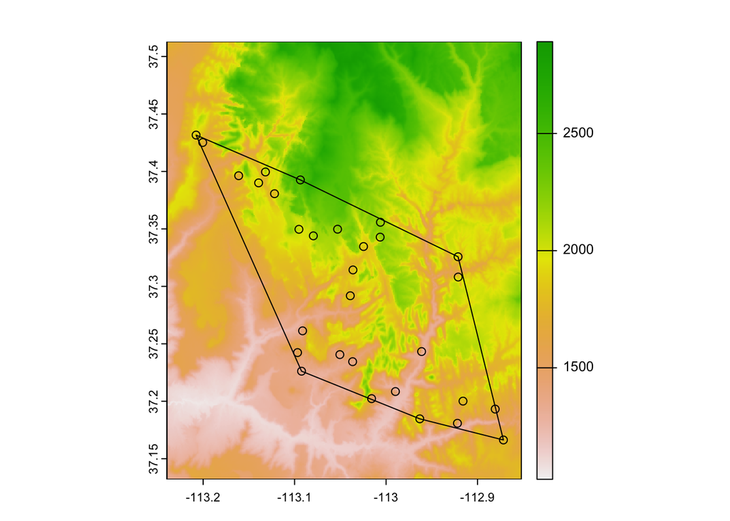

```r
zion_points_path = system.file("vector/zion_points.gpkg", package = "spDataLarge")
zion_points = read_sf(zion_points_path)
srtm = rast(system.file("raster/srtm.tif", package = "spDataLarge"))
ch = st_combine(zion_points) |>
  st_convex_hull() |>
  st_as_sf()

# Plot the data to understand their geography
plot(srtm)
plot(zion_points, add =TRUE)
plot(ch, add = TRUE)
```

## Explore and answer the following questions.

Q1.1. Crop the srtm raster using (1) the zion_points dataset and (2) the ch dataset. Are there any differences in the output maps?

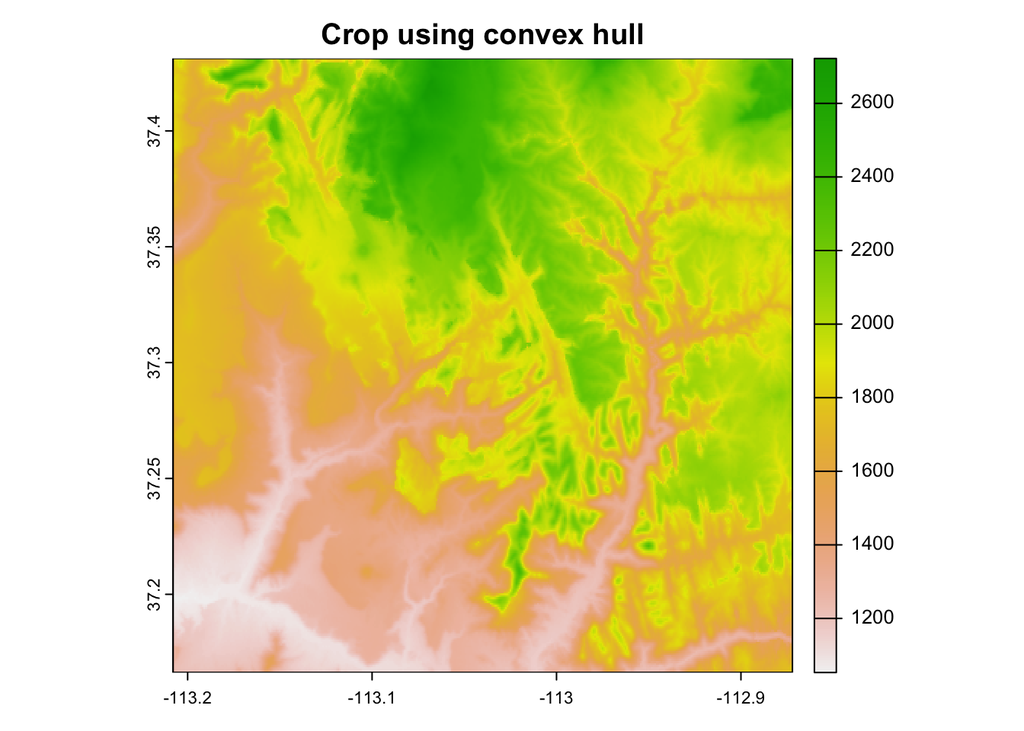

```r
# cropping using ch dataset
srtm_ch_crop = crop(srtm, ch)
plot(srtm_ch_crop, main = "Crop using convex hull")
points(coords, col = "blue", pch = 20, cex = 1.5)
```

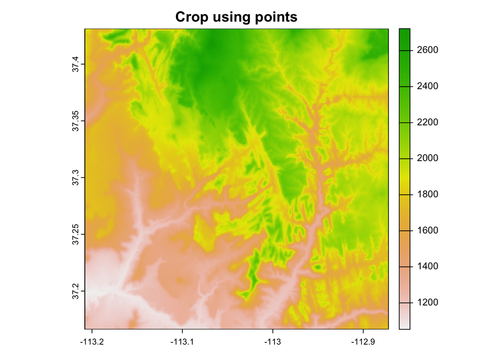

```r
# cropping using zion-points dataset
srtm_points_crop = crop(srtm, zion_points)
plot(srtm_points_crop, main = "Crop using points")
points(coords, col = "red", pch = 20, cex = 1.5)
```

Are there any differences in the cropped maps? Why? *There are no differences in the cropped maps, this may happen because there are no differnces between the 2 cropped maps because the boundary area for cropping is likely the same. Therefore the crops of the 2 maps may be identical leading to identical maps.*

Q1.2. Instead of cropping, mask srtm with zion_points and ch. Are there any differences in the output maps? If so, why?

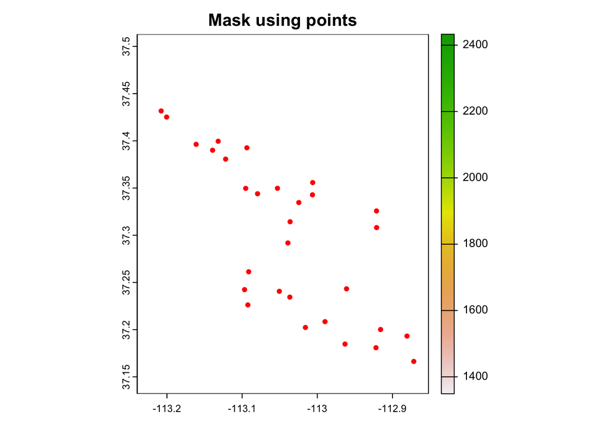

```r
# masking SRTM with zion_points
srtm_points_mask <- mask(srtm, zion_points)

# masking SRTM with ch
srtm_ch_mask <- mask(srtm, ch)

# plotting the masked SRTM with points
plot(srtm_points_mask, main = "Mask using points")
plot(st_geometry(zion_points), add = TRUE, col = 'red', pch = 20)
```

[figure not shown]

```r
# plotting the masked SRTM with ch
plot(srtm_ch_mask, main = "Mask using convex hull")
plot(st_geometry(ch), add = TRUE, col = 'blue', pch = 20)
```

Are there any differences in the masked maps? Why? *There are differences between the masked maps, the map masked using points only displays elevation at the exact point locations. On the other hand, the map that is masked using the convex hull shows elevation data for teh entire area that is covered by the convex hull polygon generated from the points therefore creating the shape instead of isolated points.*

Q2. Extract elevation values: (1) Extract values from the srtm raster with zion_points. (2) Next, extract average (mean) values of srtm using a 500-meter buffer around each point (in zion_points). (3) Compare these two sets of values in the same layer (dataframe).

```r
# step 1
elevations_at_points <- extract(srtm, zion_points)

# step 2
buffers_500m <- st_buffer(zion_points, dist = 500)
mean_elevations_in_buffers <- extract(srtm, buffers_500m, fun = mean, na.rm = TRUE)

# step 3
elevations_df <- as.data.frame(elevations_at_points)
elevations_df$mean_elevation_in_buffer = mean_elevations_in_buffers
names(elevations_df) <- c("elevation at zion point", "mean elevation in buffer")
print(elevations_df)
```

```
##    elevation at zion point mean elevation in buffer NA.ID  NA.srtm
## 1                        1                     1802     1 1794.744
## 2                        2                     2433     2 2438.034
## 3                        3                     1886     3 1903.034
## 4                        4                     1370     4 1416.175
## 5                        5                     1452     5 1346.714
## 6                        6                     1635     6 1669.432
## 7                        7                     1380     7 1430.655
## 8                        8                     2032     8 2024.696
## 9                        9                     1830     9 1833.383
## 10                      10                     1860    10 1888.641
## 11                      11                     1440    11 1513.067
## 12                      12                     2145    12 2144.465
## 13                      13                     1942    13 1873.798
## 14                      14                     1691    14 1800.949
```

[output cut: 16 more lines]

When would extracting values by buffers be more suitable than by points alone?

*Its more suitable to use buffers when extracting values in cases where you need to account for the area around a point to get an averaged measure. Its also suitable when the data points may be imprecise because buffers will ensure that the important areas are still included during the analysis.*

Q3. Rasterize elevation points: (1) Subset points higher than 3100 meters in New Zealand (the nz_height object). (2) Create a template raster with a resolution of 3 km for the extent of the new point dataset. (3) Using these two new objects, rasterize the points to display the number of points>3100m (count) in each grid cell. Plot the result. (4) Now rasterize the poings to display the maximum elevation point in each 3km grid cell. Plot the result.

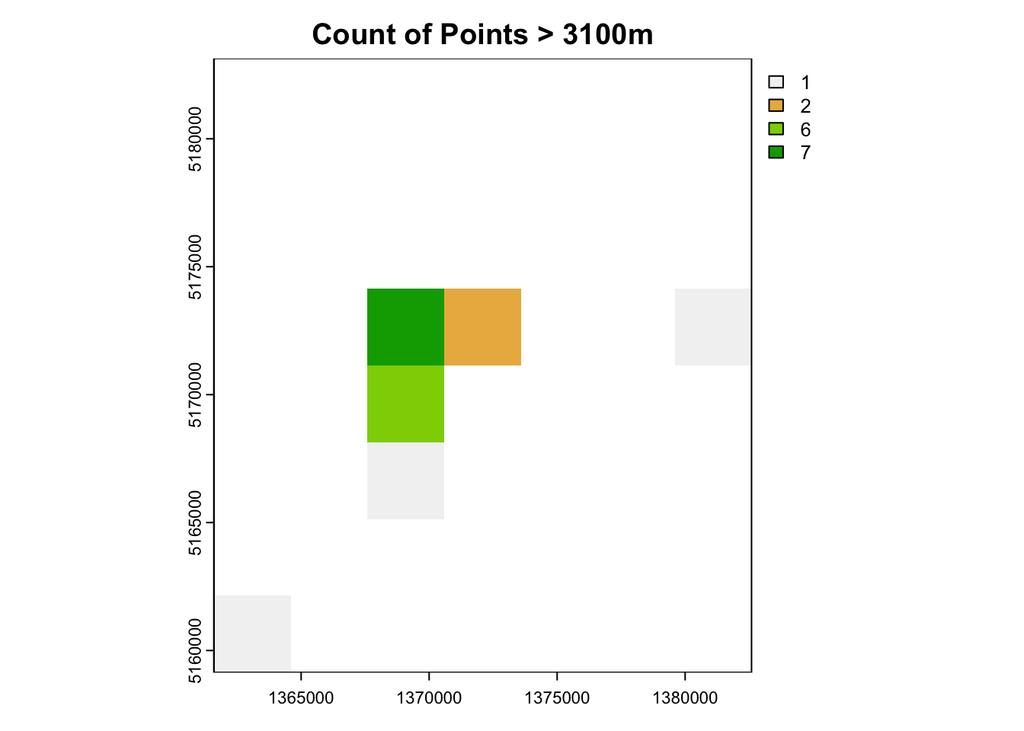

```r
# step 1
high_points <- nz_height %>% filter(elevation > 3100)
points_extent <- st_bbox(high_points)

# step 2
template_raster <- rast(extent = points_extent, res = 3000) # Resolution in meters
count_raster <- rasterize(x = high_points, y = template_raster, field = 1, fun = 'count')
max_elev_raster <- rasterize(x = high_points, y = template_raster, field = "elevation", fun = max)

# step 3
plot(count_raster, main = "Count of Points > 3100m")
```

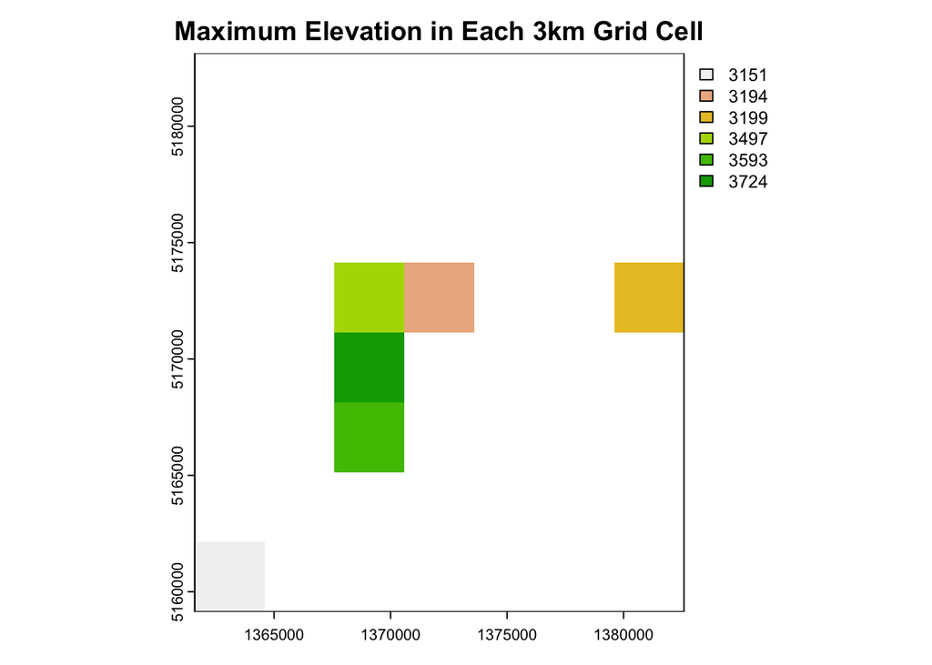

```r
# step 4
plot(max_elev_raster, main = "Maximum Elevation in Each 3km Grid Cell")
```

Q4. Raster Local operations (4.3.3) and Zonal operations (4.3.5): (1) Using local operations, use *dem = rast(system.file(“raster/dem.tif”, package = “spDataLarge”))* and reclassify the elevation in three classes: low (<300), medium (300-500), and high (>500). (2) Then with zonal operations, read the NDVI raster (ndvi = rast(system.file(“raster/ndvi.tif”, package = “spDataLarge”))) and compute the mean NDVI *and* the mean elevation for each altitudinal class.

```r
# step 1
dem = rast(system.file("raster/dem.tif", package = "spDataLarge"))
reclass_matrix <- matrix(c(-Inf, 300, 1,  # low
                           300, 500, 2,   # medium
                           500, Inf, 3),  # high
                         byrow = TRUE, ncol = 3)
reclassified_dem <- classify(dem, rcl = reclass_matrix)

# step 2
ndvi = rast(system.file("raster/ndvi.tif", package = "spDataLarge"))
mean_ndvi_by_class <- zonal(ndvi, reclassified_dem, fun = "mean")
mean_elevation_by_class <- zonal(dem, reclassified_dem, fun = "mean")
print(mean_ndvi_by_class)
```

```
##   dem       ndvi
## 1   1 -0.3631755
## 2   2 -0.2893352
## 3   3 -0.2075496
```

```r
print(mean_elevation_by_class)
```

```
##   dem    dem.1
## 1   1 274.3910
## 2   2 392.0486
## 3   3 765.2197
```

Q5. Use the Landsat image provided by the spDataLarge package: *rast(system.file(“raster/landsat.tif”, package = “spDataLarge”))* to calculate the Normalized Difference Water Index (NDWI; (green - nir)/(green + nir)) of the image. NDWI is similar to NDVI (see Section 4.3.3) except that NDVI is to enhance the appearance of vegetation from a multispectral image whereas NDWI is to enhance the appearance of water.

Hint: For NDVI and NDWI calculation, please follow the procedure described in Section 4.3.3 of Chapter 4. As described in Chapter 4, the image (which is a Landsat level-2 product) has four spectral bands from the Landsat 8 satellite — blue (band 1 in the image), green (band 2), red (band 3), and near-infrared (NIR, band 4). The Landsat level-2 products are stored as integers to save disk space, and thus we need to convert them to floating-point numbers before doing any calculations. For that purpose, we need to apply a scaling factor (0.0000275) and add an offset (-0.2) to the original values

Bonus: 1 point. Calculate a correlation between NDVI and NDWI for this area. You can use the [layerCor()](https://rspatial.github.io/terra/reference/layerCor.html) function, and refer to Section 3.3.1 in Chapter 3 for stacking multilayered rasters.

```r
# load the landsat image and apply scaling factor and offset based on requirements
landsat <- rast(system.file("raster/landsat.tif", package = "spDataLarge"))
landsat_scaled <- (landsat * 0.0000275) - 0.2

# extract the necessary bands
green <- landsat_scaled[[2]]
nir <- landsat_scaled[[4]]
red <- landsat_scaled[[3]]

# calculating NDWI
ndwi <- (green - nir) / (green + nir)

# calculating NDVI
ndvi <- (nir - red) / (nir + red)

# bonus question
ndvi_values <- values(ndvi)
ndwi_values <- values(ndwi)
valid_indices <- !is.na(ndvi_values) & !is.na(ndwi_values)
ndvi_valid <- ndvi_values[valid_indices]
ndwi_valid <- ndwi_values[valid_indices]
correlation_value <- cor(ndvi_valid, ndwi_valid)
print(correlation_value)
```

```
## [1] -0.001925882
```

Render your document by clicking on the “Knit” option in RStudio. Upload the .html file to your assignment submission!

.